# 3 Chi-Square Test

# 3.1 The Purpose

**Chi-square test** is a nonparametric test used for two specific purposes:

1. To test the hypothesis of no association between two or more groups, population or criteria (i.e. to check independence between two variables)
2. and to test how likely the observed distribution of data fits with the distribution that is expected (i.e., to test the goodness-of-fit).

It is used to analyze categorical data (e.g. male or female patients, smokers and non-smokers, etc.), it is not meant to analyze parametric or continuous data (e.g., height measured in centimeters or weight measured in kg, etc.).

For example, if we want to test that in a health camp attended by 50 persons the one who exercise regularly are having lesser body mass index (BMI) by taking their actual BMI values, than it cannot be tested using a Chi-square test. However, if we divide the same set of 50 persons into two categories as obese with BMI > 30 and nonobese with BMI < 30, than the same data can be tested using a Chi-square test by counting the number of obese and nonobese persons across two groups, the one who exercise regularly and the one who does not. A 2x2 cross tables can be constructed for calculating a Chi-square statistic.

# 3.2 Case Study: Effectiveness of a Drug Treatment

Let’s consider a case where we test the effectiveness of a drug for diabetes.

Suppose we have 105 patients under study and 50 of them were treated with the drug. The remaining 55 patients were kept as control samples. The health condition of all patients was checked after a week.

Based on this, we can define our hypothesis:

- Ho: The two variables are independent
- Ha: The two variables are related.

The following table shows if their condition improved or not. Just by looking at it, can you tell if the drug had a positive effect on the patients.

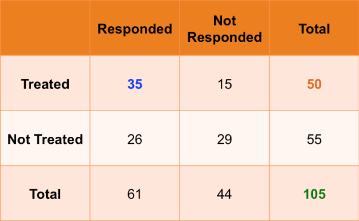

As you can see, 35 out of the 50 patients showed improvement. Suppose if the drug had no effect, the 50 would have been split the same proportion as the patients who were not given the treatment. But in this case, about 70% of patients showed improvement, which is significantly higher than the control case.

Since both categorical variables have only 2 levels, it was sort of intuitive to say that the drug treatment and health condition are dependent. But, as the number of categories increase, we need a quantifiable statistic to definitively say if they are dependent or not. One such a metric is the **chi-squared statistic**.

# 3.3 Chi-Squared Statistic

The Chi-square statistic is a tool designed to analyze group differences when the dependent variable is measured at a nominal level.

The general formula for calculating the expected counts from observed count for a particular cell is:

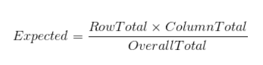

Before we proceed further, we need to know how many degrees of freedom (DF) we have, when a comparison is made between one sample and another

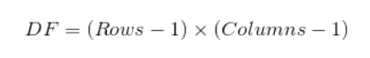

For sake of understanding, lets see how the expected values are computed for the 2 by 2 case. The first cell will take the value: 50 times 61 by 105, which equals 29.04. All the expected values can be computed this way (shown in brackets).

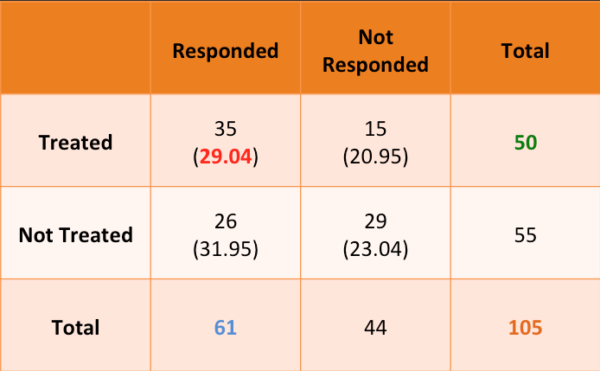

The Chi-square statistic numeric computation as follows:

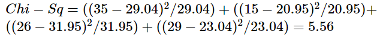

For this analysis, the significance level is 0.05.

Since there are two categories, the degrees of freedom = 1 [DF = (2 - 1) x (2 - 1) = 1 x 1 = 1)

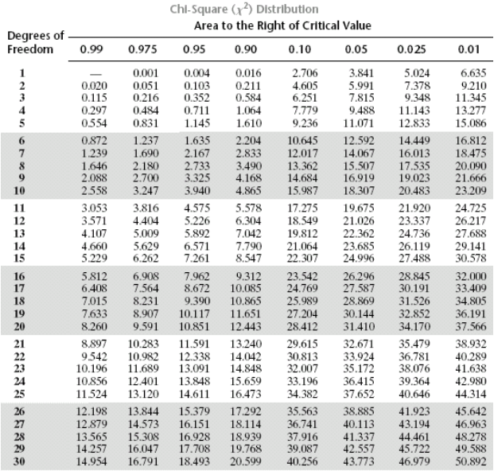

From the chi-squared table above we find that the critical value is 3.84 for 1 degrees of freedom at the alpha = 0.05 level. Since 5.56 is greater than the critical value, we reject the null hypothesis.

# 3.4 Chi-Square Test of Independence

The **chi-square test of independence** is one of the most basic and common hypothesis tests in the statistical analysis of categorical data. Given two categorical random variables x and y, the chi-square test of independence determines whether or not there exists a statistical dependence between them.

Like all statistical tests, chi-square test of independence assumes a null hypothesis and an alternate hypothesis. The general practice is, if the p-value that comes out in the result is less than a pre-determined significance level, which is 0.05 usually, then we reject the null hypothesis.

The null hypothesis of the chi-squared test of independence is that the two variables are independent and the alternate hypothesis is that they are related.

## 3.4.1 Use Case: **Road Accident and Holidays** Dataset

In this example, we will test whether there is an association in road accident data between the type of road and holiday periods. The study examines road accident in Victoria during its school and public holiday periods compared against the remainder of the year.

We will begin with importing our holiday list data.

```r
holidays = read.csv("https://raw.githubusercontent.com/insaid2018/R/master/Data/holidaylist.csv", header = TRUE)
```

```r
View(holidays)
```

```r
str(holidays)
```

```
'data.frame':   180 obs. of  1 variable:
 $ holiday_date: int  20190101 20190128 20190311 20190419 20190420 20190421 20190422 20190425 20190527 20190610 ...
```

Now, lets import our road accident data.

```r
master_all = read.csv("https://raw.githubusercontent.com/insaid2018/R/master/Data/Crashes_Last_Five_Years.csv", header = TRUE, stringsAsFactors = TRUE, na.strings = c("","NA"))
```

```r
View(master_all)
```

```r
str(master_all)
```

```
'data.frame':   72284 obs. of  65 variables:
 $ ï..X             : num  145 145 144 145 145 ...
 $ Y                : num  -37.5 -37.8 -38.2 -37.8 -37.7 ...
 $ OBJECTID         : int  3145907 3145908 3145909 3145910 3145911 3145912 3145913 3145914 3145915 3145916 ...
 $ ACCIDENT_NO      : Factor w/ 72284 levels "T20130013608",..: 2576 2577 2773 2774 2775 2776 2777 2778 2779 2780 ...
 $ ABS_CODE         : Factor w/ 1 level "ABS to receive accident": 1 1 1 1 1 1 1 1 1 1 ...
 $ ACCIDENT_STATUS  : Factor w/ 2 levels "Finished","Reopened": 1 1 1 1 1 1 1 1 1 1 ...
 $ ACCIDENT_DATE    : Factor w/ 2006 levels "1/1/2014","1/1/2015",..: 655 523 919 1051 1051 985 853 1051 1051 589 ...
 $ ACCIDENT_TIME    : Factor w/ 1419 levels "00.00.00","00.01.00",..: 535 1241 860 750 1015 930 1180 1085 1210 252 ...
 $ ALCOHOLTIME      : Factor w/ 2 levels "No","Yes": 1 2 2 1 1 1 2 2 2 2 ...
 $ ACCIDENT_TYPE    : Factor w/ 9 levels "Collision with a fixed object",..: 3 3 3 3 3 3 3 3 8 1 ...
 $ DAY_OF_WEEK      : Factor w/ 7 levels "Friday","Monday",..: 7 2 3 2 2 4 1 2 2 6 ...
 $ DCA_CODE         : Factor w/ 81 levels "ACCIDENT OR BROKEN DOWN",..: 9 18 3 9 55 55 55 74 51 17 ...
 $ HIT_RUN_FLAG     : Factor w/ 3 levels "No","Not known",..: 1 1 1 1 1 1 1 1 1 1 ...
 $ LIGHT_CONDITION  : Factor w/ 7 levels "Dark No street lights",..: 5 3 5 5 5 5 3 3 3 3 ...
```

[output cut: 51 more lines]

There are 72284 observations and 65 variables in the accident data.

Since we are only interested in the accident dates and the road types where accidents occured, we will keep variables Accident_Date and RMA.

```r
#Lets keep these two variables 'Accident_Date' and 'RMA' (which refers to RMA Road classification eg. arteri, highway,freeway, etc)
variables_of_interest = c("ACCIDENT_DATE","RMA")
```

```r
master = master_all[variables_of_interest]
```

```r
str(master)
```

```
'data.frame':   72284 obs. of  2 variables:
 $ ACCIDENT_DATE: Factor w/ 2006 levels "1/1/2014","1/1/2015",..: 655 523 919 1051 1051 985 853 1051 1051 589 ...
 $ RMA          : Factor w/ 5 levels "Arterial Highway",..: 2 2 1 2 2 2 2 4 1 2 ...
```

Let’s look at the details of the accident data.

```r
summary(master)
```

```
    ACCIDENT_DATE                 RMA
 17/4/2015 :   77   Arterial Highway:13413
 29/4/2016 :   67   Arterial Other  :26294
 9/12/2015 :   67   Freeway         : 5298
 4/12/2015 :   66   Local Road      :25801
 18/12/2014:   64   Non Arterial    :   16
 9/4/2014  :   64   NA's            : 1462
 (Other)   :71879
```

There are 1462 missing values in the RMA variable, which represents 2% of total observations. Missing values are a common problem in data analysis, and can lead to biased statistical conclusion in some cases.

Since in our case, the amount of missing data values is relatively small (i.e. less than 5%), leaving out observations with missing values may be the best strategy in order not to bias the result.

```r
# To remove RMA variable that has missing value.
master = na.omit(master, cols = "RMA")
```

```r
View(master)
```

Next, we want to combine these two data sets based on Holiday_Date and Accident_Date by formatting dates.

```r
holidays$holiday_date = as.Date(as.character(holidays$holiday_date),"%Y%m%d")
```

```r
View(holidays)
```

```r
master$ACCIDENT_DATE = as.Date(as.character(master$ACCIDENT_DATE),"%d/%m/%Y")
```

```r
View(master)
```

Now, the result of date formatting works well

```r
head(holidays, 5)
```

|  | holiday_date |
| --- | --- |
| 1 | 2019-01-01 |
| 2 | 2019-01-28 |
| 3 | 2019-03-11 |
| 4 | 2019-04-19 |
| 5 | 2019-04-20 |

```r
str(holidays)
```

```
'data.frame':   180 obs. of  1 variable:
 $ holiday_date: Date, format: "2019-01-01" "2019-01-28" "2019-03-11" ...
```

```r
head(master$ACCIDENT_DATE,5)
```

```
[1] "2013-09-18" "2013-09-16" "2013-09-21" "2013-09-23" "2013-09-23"
```

```r
str(master)
```

```
'data.frame':   70822 obs. of  2 variables:
 $ ACCIDENT_DATE: Date, format: "2013-09-18" "2013-09-16" "2013-09-21" ...
 $ RMA          : Factor w/ 5 levels "Arterial Highway",..: 2 2 1 2 2 2 2 4 1 2 ...
 - attr(*, "na.action")= 'omit' Named int  15 18 22 48 58 246 261 262 270 289 ...
  ..- attr(*, "names")= chr  "15" "18" "22" "48" ...
```

Now, we classify the data so that road accident that happened during holiday = True. And we will store this data in variable “holiday”

```r
interesting.dates = c(holidays$holiday_date)
```

```r
is.interesting = master$ACCIDENT_DATE %in% interesting.dates
not.interesting = ! ( master$ACCIDENT_DATE %in% interesting.dates)
```

```r
# to create new variable called holiday
master$holiday <- is.interesting
str(master)
```

```
'data.frame':   70822 obs. of  3 variables:
 $ ACCIDENT_DATE: Date, format: "2013-09-18" "2013-09-16" "2013-09-21" ...
 $ RMA          : Factor w/ 5 levels "Arterial Highway",..: 2 2 1 2 2 2 2 4 1 2 ...
 $ holiday      : logi  FALSE FALSE FALSE FALSE FALSE FALSE ...
 - attr(*, "na.action")= 'omit' Named int  15 18 22 48 58 246 261 262 270 289 ...
  ..- attr(*, "names")= chr  "15" "18" "22" "48" ...
```

```r
View(master)
```

```r
unique(master$holiday)
```

```
[1] FALSE  TRUE
```

```r
table(master$holiday)
```

```
FALSE  TRUE
67473  3349
```

Ultimately we want to be able to classify that

- holiday variable = True is classified as Holiday Season
- holiday variable = False is classified as Non Holiday Season

and we store it in variable “season”

```r
master$season <- ifelse(master$holiday == "TRUE", "Holiday", "Non Holiday")
```

```r
View(master)
```

```r
table(master$season)
```

```
    Holiday Non Holiday
       3349       67473
```

Creating Contingency Table

```r
# to create a contingency table of occurrences
mytable <- table(master$season, master$RMA)
knitr::kable(mytable)
```

|  | Arterial Highway | Arterial Other | Freeway | Local Road | Non Arterial |
| --- | --- | --- | --- | --- | --- |
| Holiday | 680 | 1188 | 210 | 1270 | 1 |
| Non Holiday | 12733 | 25106 | 5088 | 24531 | 15 |

We can visualize this using bar plot from ggplot2 package

```r
library(ggplot2)
```

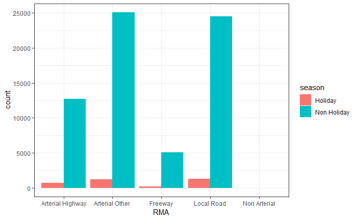

```r
graph <- ggplot(data=master, aes(RMA)) +geom_bar(aes(fill=season),position = "dodge")+ theme_bw()
graph
```

The graph and table show there are only a very small number of observations in the road type = Non Arterial.

Chi Square Test of Independence

Our hypotheses are:

Ho: Type of road and holiday period are independent variables. There is no association in Victoria road accident between type of road and holiday period.

Ha: Type of road and holiday period are dependent variables, which suggests association in Victoria road accident between type of road and holiday period.

To accept or reject the null hypothesis, we choose significance level of 0.05

```r
chi2 <- chisq.test(mytable, correct=TRUE)
```

```
Chi-squared approximation may be incorrect
```

```r
chi2
```

```
    Pearson's Chi-squared test

data:  mytable
X-squared = 15.159, df = 4, p-value = 0.004382
```

```r
chi2$expected
```

```
              Arterial Highway Arterial Other   Freeway Local Road Non Arterial
  Holiday             634.2681       1243.379  250.5295   1220.066    0.7566011
  Non Holiday       12778.7319      25050.621 5047.4705  24580.934   15.2433989
```

The chi-square distribution provides a good approximation if no more than 20% of the expected counts are less than 5 and all individual expected counts are 1 or greater.

In our example there is one cell (10% of total cells) with expected number less than 5. Also, there is one cell with expected number less than 1. The Chi Square is therefore not the appropriate method to test the independence. Hence the warning message.

Correcting the Situation: Pooling Method and Fisher’s Exact test

Pooling method

This method pools some values of the categorical variable together. Best practice is to pool values with adjacent meaning.

I will pool road type into 3 levels based on the responsible authorities **‘Arterial’**, **‘Freeway’**, and **’Municipal & Local Road** using collapse.table function from vcdExtra package.

```r
install.packages("vcdExtra")
```

```r
library(vcdExtra)
```

```r
# to convert variables into character levels
RMA.char = as.character(master$RMA)
```

```r
# to convert variables into character levels
Season.char = as.character(master$season)
```

```r
mytable.char = table(Season.char, RMA.char)
```

```r
# note that the ordering in RMA.char matters in pooling values together
mytable2 = collapse.table (mytable.char, RMA.char=c("Arterial","Arterial","Freeway","Muni&Local Roads","Muni&Local Roads","Muni&Local Roads"))
knitr::kable(mytable2)
```

|  | Arterial | Freeway | Muni&Local Roads |
| --- | --- | --- | --- |
| Holiday | 1868 | 210 | 1271 |
| Non Holiday | 37839 | 5088 | 24546 |

Let’s check the chi square result from our new “pooled” table

```r
new.chi2 <- chisq.test(mytable2, correct=TRUE)
new.chi2
```

```
    Pearson's Chi-squared test

data:  mytable2
X-squared = 9.0988, df = 2, p-value = 0.01057
```

The result gives a p-value of 0.01057 (Reject Ho).

If Ho is false, the observed and expected frequencies will not be close in value and the ??2 statistic will not be close to zero (our ??2 is 9.0988)

```r
new.chi2$expected
```

```
             RMA.char
Season.char    Arterial   Freeway Muni&Local Roads
  Holiday      1877.647  250.5295         1220.823
  Non Holiday 37829.353 5047.4705        24596.177
```

We can therefore conclude that there is association in Victoria road accident between type of road and holiday period.

Fisher Exact’s Test of Independence

Fisher Exact’s Test is a non-parametric test used in the analysis of 2x2 contingency tables. It is called exact test because the significance from the null hypothesis (eg. p-value) can be calculated exactly, rather than relying on an approximation.

Let’s do more pooling to create a 2x2 table to apply the Fisher’s Exact test.

```r
# to pool Arterial and Freeway roads together
mytable3 <- collapse.table(mytable2, RMA.char=c("Arterial and Freeway", "Arterial and Freeway","Muni&Local Roads"))
knitr::kable(mytable3)
```

|  | Arterial and Freeway | Muni&Local Roads |
| --- | --- | --- |
| Holiday | 2078 | 1271 |
| Non Holiday | 42927 | 24546 |

```r
fisher <- fisher.test(mytable3,conf.int = T, conf.level = 0.95, simulate.p.value = T)
fisher
```

```
    Fisher's Exact Test for Count Data

data:  mytable3
p-value = 0.0659
alternative hypothesis: true odds ratio is not equal to 1
95 percent confidence interval:
 0.8698703 1.0050030
sample estimates:
odds ratio
 0.9348694
```

Fisher’s exact test gives a p-value of 0.0659 (Accept Ho).

We can therefore conclude that there is no dependency in Victoria road accident between road type and holiday season.

Strength of Association

Chi square test is a test of association, but it does not tell the strength of association. To test the strength of association, we use either Phi or Cramer’s V test.

Cramer’s V Test

Cramer’s V test measures relative strength between two variables. The coefficient ranges from 0 (no association) to 1 (perfect association). It can be calculated using different packages which all generate the same value.

```r
# total sample size
n <- sum (mytable2)
```

```r
#min number of row and min number of column
q <- min (nrow(mytable2),ncol(mytable2))
```

```r
# to calculate chi square
chi <- chisq.test(mytable2, correct=TRUE)$statistic
```

```r
# to calculate carmer's v value using R-base
cramer_value_rbase <- sqrt(chi/n*(q-1))
cramer_value_rbase
```

```
 X-squared
0.01133466
```

```r
install.packages("lsr")
```

```r
library(lsr)
```

```r
 # to calculate carmer's v value using lsr package
cramer_value_lsr <- cramersV(mytable2)
cramer_value_lsr
```

```
[1] 0.01133466
```

```r
install.packages("DescTools")
```

```r
library(DescTools)
```

```r
# to calculate carmer's v value using DescTools package
cramer_value_desctools <- CramerV(mytable2)
cramer_value_desctools
```

```
[1] 0.01133466
```

Phi test

Similar to Cramer’s V test, Phi test measures relative strength for 2x2 contingency table.

```r
# the Phi function uses DescTools package
phi.test <- Phi(mytable3)
phi.test
```

```
[1] 0.006935316
```

Both Phi and Cramer’s V tests showed very small numbers suggesting very weak association (level of interpretation from Computing in the Humanities and Social Sciences, 2010) of road accident between road type and holiday season. This is consistent with our chi-square and Fisher’s Exact test results.

# 3.5 Chi-Square Goodness of Fit Test

The **Chi-square goodness of fit test** is a statistical hypothesis test to see how well sample data fit a distribution from a population with a normal distribution. In other words, it tells you if your sample data represents the data you would expect to find in the actual population. Goodness of fit is a statistical term referring to how far apart the expected values of a model are from the actual values.

The test is applied when you have one categorical variable from a single population. It is used to determine whether sample data are consistent with a hypothesized distribution.

**When to Use the Chi-Square Goodness of Fit Test**

The chi-square goodness of fit test is appropriate when the following conditions are met:

- The sampling method is simple random sampling.
- The variable under study is categorical.
- The expected value of the number of sample observations in each level of the variable is at least 5.

## 3.5.1 Use Case: **Mobiles Sales** Dataset

Chroma, an electronics company sells mobile phones. The company claims that 30% of the phones are Oneplus, 60% are Apple, and 10% are Samsung.

Suppose a random sample of 1000 phones has 500 iphones, 450 Oneplus, and 50 Samsung. Is this consistent with Chroma’s claim? Use a 0.05 level of significance.

- **Null Hypothesis**: The proportion of Oneplus, Apple, and Samsung is 30%, 60% and 10%, respectively.
- **Alternative Hypothesis**: At least one of the proportions in the null hypothesis is false.

For this analysis, the significance level is 0.05. Using sample data, we will conduct a chi-square goodness of fit test of the null hypothesis.

```r
sample_data = c(500, 450, 50)
```

```r
claim.prop = c(0.60, 0.30, 0.10)
```

```r
chisq.test(sample_data,p = claim.prop)
```

```
    Chi-squared test for given probabilities

data:  sample_data
X-squared = 116.67, df = 2, p-value < 2.2e-16
```

Since the P-value is less than the significance level (0.05), we cannot accept the null hypothesis.

In the built-in data set survey, the Smoke column records the survey response about the student’s smoking habit.

```r
library(MASS)
```

```r
View(survey)
```

```r
table(survey$Smoke)
```

```
Heavy Never Occas Regul
   11   189    19    17
```

As there are exactly four proper response in the survey: “Heavy”, “Regul” (regularly), “Occas” (occasionally) and “Never”. It can be confirmed with the levels function in R.

```r
levels(survey$Smoke)
```

```
[1] "Heavy" "Never" "Occas" "Regul"
```

We can find the frequency distribution with the table function.

```r
smoke.freq = table(survey$Smoke)
smoke.freq
```

```
Heavy Never Occas Regul
   11   189    19    17
```

```r
prop.table(smoke.freq)
```

```
     Heavy      Never      Occas      Regul
0.04661017 0.80084746 0.08050847 0.07203390
```

```r
round(prop.table(smoke.freq),2)
```

```
Heavy Never Occas Regul
 0.05  0.80  0.08  0.07
```

```r
round(prop.table(smoke.freq),3)*100
```

```
Heavy Never Occas Regul
  4.7  80.1   8.1   7.2
```

```r
paste(round(prop.table(smoke.freq),3)*100, "%", sep = "")
```

```
[1] "4.7%"  "80.1%" "8.1%"  "7.2%"
```

We save the campus smoking statistics in a variable named smoke.prob.

```r
smoke.prob = c(0.047, 0.800, 0.081, 0.072)
```

Then we apply the chisq.test function and perform the Chi-Squared test.

```r
chisq.test(smoke.freq, p = smoke.prob)
```

```
    Chi-squared test for given probabilities

data:  smoke.freq
X-squared = 0.0016826, df = 3, p-value = 1
```

As the p-value is greater than the 0.05 significance level, we do not reject the null hypothesis that the sample data in survey supports the campus-wide smoking statistics.